# Python In R

David R. Feinberg

November 27, 2019

R doesn’t have to be hard. Start with R Commander

```r
#install.packages('Rcmdr)
library('Rcmdr')
library(reticulate)
path_to_python <- "/home/david/anaconda3/bin/python"
use_python(path_to_python)
py_config()
```

```
## python:         /home/david/anaconda3/bin/python
## libpython:      /home/david/anaconda3/lib/libpython3.7m.so
## pythonhome:     /home/david/anaconda3:/home/david/anaconda3
## version:        3.7.3 (default, Mar 27 2019, 22:11:17)  [GCC 7.3.0]
## numpy:          /home/david/anaconda3/lib/python3.7/site-packages/numpy
## numpy_version:  1.16.2
##
## python versions found:
##  /home/david/anaconda3/bin/python
##  /usr/bin/python
##  /usr/bin/python3
##  /home/david/anaconda2/bin/python
```

```r
parselmouth <- import("parselmouth.praat")
praat <- import("parselmouth")
```

```r
voiceID <- '/home/david/Dropbox/Python3/Praat/audio/m1750_hi.wav'
f0min <- 75
f0max <- 300
unit <- "Hertz"
sound <- praat$Sound(voiceID)
duration <- parselmouth$call(sound, "Get total duration") # duration
pitch <- parselmouth$call(sound, "To Pitch", 0.0, f0min, f0max) #create a praat pitch object
meanF0 <- parselmouth$call(pitch, "Get mean", 0, 0, unit) # get mean pitch
stdevF0 <- parselmouth$call(pitch, "Get standard deviation", 0 ,0, unit) # get standard deviation
duration
```

```
## [1] 9.473741
```

```r
meanF0
```

```
## [1] 117.9415
```

```r
stdevF0
```

```
## [1] 19.25767
```

```python
import parselmouth
import pandas as pd
from parselmouth.praat import call
from glob import glob

def measurePitch(voiceID, f0min, f0max, unit):
    sound = parselmouth.Sound(voiceID) # read the sound
    duration = call(sound, "Get total duration") # duration
    pitch = call(sound, "To Pitch", 0.0, f0min, f0max) #create a praat pitch object
    meanF0 = call(pitch, "Get mean", 0, 0, unit) # get mean pitch
    stdevF0 = call(pitch, "Get standard deviation", 0 ,0, unit) # get standard deviation
    return duration, meanF0, stdevF0



filelist  = glob('/home/david/Dropbox/Python3/Praat/audio/*.wav')
filelist.sort()
f0min = 75
f0max = 300
unit = "Hertz"
durations = [measurePitch(wavfile, f0min, f0max, unit)[0] for wavfile in filelist]
pitches = [measurePitch(wavfile, f0min, f0max, unit)[1] for wavfile in filelist]
stdevs = [measurePitch(wavfile, f0min, f0max, unit)[2] for wavfile in filelist]
factor = [0,0,0,0,0,0,0,1,1,1,1,1,1,1]
measures = [durations, pitches, stdevs]
df = pd.DataFrame()
df['duration'] = durations
df['pitch'] = pitches
df['stdev_of_pitch'] = stdevs
df['factor'] = factor
df.to_csv('data_generated_from_python.csv')

print(df.head())
```

```
##    duration       pitch  stdev_of_pitch  factor
## 0  9.473741  117.941529       19.257674       0
## 1  2.475057   87.161592       11.229807       0
## 2  3.795215  109.815510        9.799586       0
## 3  4.458231  115.803693       13.883171       0
## 4  7.894785  139.737919       15.666261       0
```

```r
df <- read.csv('data_generated_from_python.csv')
names(df)[names(df) == "X"] <- "participant"
head(df)
```

```
##   participant duration     pitch stdev_of_pitch factor
## 1           0 9.473741 117.94153      19.257674      0
## 2           1 2.475057  87.16159      11.229807      0
## 3           2 3.795215 109.81551       9.799586      0
## 4           3 4.458231 115.80369      13.883171      0
## 5           4 7.894785 139.73792      15.666261      0
## 6           5 1.977007 109.11364      20.020560      0
```

```r
x = unlist(df['duration'])
y = unlist(df['pitch'])
cor.test(x,y)
```

```
##
##  Pearson's product-moment correlation
##
## data:  x and y
## t = 0.078693, df = 12, p-value = 0.9386
## alternative hypothesis: true correlation is not equal to 0
## 95 percent confidence interval:
##  -0.5140630  0.5467027
## sample estimates:
##        cor
## 0.02271099
```

```r
library('lmerTest')
library('tidyverse')
```

Random slopes and intercepts model, specifying slopes and intercepts maximally

```r
model <- lmer(pitch ~ duration + stdev_of_pitch + (1 + stdev_of_pitch | factor), data=df)
```

```
## boundary (singular) fit: see ?isSingular
```

```r
summary(model)
```

```
## Linear mixed model fit by REML. t-tests use Satterthwaite's method [
## lmerModLmerTest]
## Formula: pitch ~ duration + stdev_of_pitch + (1 + stdev_of_pitch | factor)
##    Data: df
##
## REML criterion at convergence: 102.8
##
## Scaled residuals:
##      Min       1Q   Median       3Q      Max
## -1.61582 -0.47337  0.00741  0.50437  1.84674
##
## Random effects:
##  Groups   Name           Variance  Std.Dev.  Corr
##  factor   (Intercept)    2.712e-07 5.208e-04
##           stdev_of_pitch 1.013e-09 3.183e-05 -1.00
##  Residual                1.929e+02 1.389e+01
## Number of obs: 14, groups:  factor, 2
##
## Fixed effects:
##                Estimate Std. Error       df t value Pr(>|t|)
## (Intercept)    97.65889   11.68311 11.00000   8.359 4.29e-06 ***
## duration       -0.05128    1.04390 11.00000  -0.049    0.962
## stdev_of_pitch  1.07475    0.73634 11.00000   1.460    0.172
## ---
## Signif. codes:  0 '***' 0.001 '**' 0.01 '*' 0.05 '.' 0.1 ' ' 1
##
## Correlation of Fixed Effects:
##             (Intr) duratn
## duration    -0.542
## stdv_f_ptch -0.726 -0.090
## convergence code: 0
## boundary (singular) fit: see ?isSingular
```

This example is from: https://neuropsychology.github.io/psycho.R/2018/05/01/repeated_measure_anovas.html

How to do an ANOVA in R Step 1, Stop using ANOVA Step 2, use linear mixed-effects designs instead

```r
#load the rda file
emotion <- load(file = "/home/david/Scientific-Computing/Lectures/emotion.rda")
head(emotion)
```

```
## [1] "emotion"
```

```r
#install.packages('tidyverse')
library(psycho)
library(tidyverse)

df <- psycho::emotion %>%
  select(Participant_ID,
         Participant_Sex,
         Emotion_Condition,
         Subjective_Valence,
         Recall)

summary(df)
```

```
##  Participant_ID Participant_Sex Emotion_Condition Subjective_Valence
##  10S    : 48    Female:720      Negative:456      Min.   :-100.000
##  11S    : 48    Male  :192      Neutral :456      1st Qu.: -65.104
##  12S    : 48                                      Median :  -2.604
##  13S    : 48                                      Mean   : -18.900
##  14S    : 48                                      3rd Qu.:   7.000
##  15S    : 48                                      Max.   : 100.000
##  (Other):624
##    Recall
##  Mode :logical
##  FALSE:600
##  TRUE :312
##
##
##
##
```

Repeated measures ANOVA

```r
anova_model <-aov(Subjective_Valence ~ Emotion_Condition + Error(Participant_ID/Emotion_Condition), data=df)
summary(anova_model)
```

```
##
## Error: Participant_ID
##           Df Sum Sq Mean Sq F value Pr(>F)
## Residuals 18 115474    6415
##
## Error: Participant_ID:Emotion_Condition
##                   Df  Sum Sq Mean Sq F value   Pr(>F)
## Emotion_Condition  1 1278417 1278417   245.9 6.11e-12 ***
## Residuals         18   93573    5198
## ---
## Signif. codes:  0 '***' 0.001 '**' 0.01 '*' 0.05 '.' 0.1 ' ' 1
##
## Error: Within
##            Df Sum Sq Mean Sq F value Pr(>F)
## Residuals 874 935646    1070
```

```r
fit <- lmer(Subjective_Valence ~ Emotion_Condition + (1|Participant_ID), data=df)
summary(fit)
```

```
## Linear mixed model fit by REML. t-tests use Satterthwaite's method [
## lmerModLmerTest]
## Formula: Subjective_Valence ~ Emotion_Condition + (1 | Participant_ID)
##    Data: df
##
## REML criterion at convergence: 9041.9
##
## Scaled residuals:
##     Min      1Q  Median      3Q     Max
## -2.6040 -0.6754 -0.2227  0.6613  3.1385
##
## Random effects:
##  Groups         Name        Variance Std.Dev.
##  Participant_ID (Intercept)  109.6   10.47
##  Residual                   1153.8   33.97
## Number of obs: 912, groups:  Participant_ID, 19
##
## Fixed effects:
##                          Estimate Std. Error      df t value Pr(>|t|)
## (Intercept)               -56.340      2.881  25.041  -19.56   <2e-16 ***
## Emotion_ConditionNeutral   74.881      2.250 892.000   33.29   <2e-16 ***
## ---
## Signif. codes:  0 '***' 0.001 '**' 0.01 '*' 0.05 '.' 0.1 ' ' 1
##
## Correlation of Fixed Effects:
##             (Intr)
## Emtn_CndtnN -0.390
```

```r
head(df)
```

```
##   Participant_ID Participant_Sex Emotion_Condition Subjective_Valence
## 1             1S          Female           Neutral          0.5208333
## 2             1S          Female           Neutral          4.1666667
## 3             1S          Female           Neutral         25.5208333
## 4             1S          Female           Neutral          0.0000000
## 5             1S          Female           Neutral         45.8333333
## 6             1S          Female           Neutral          0.0000000
##   Recall
## 1   TRUE
## 2  FALSE
## 3   TRUE
## 4  FALSE
## 5  FALSE
## 6  FALSE
```

Here we’ll centre our response variable so that effects make sense. Then we’ll replace our Dummy Coding (R’s default) with Effect Coding http://talklab.psy.gla.ac.uk/tvw/catpred/

```r
df$Subjective_Valence_centred <- df$Subjective_Valence - mean(df$Subjective_Valence)


df$Emotion_Condition2[df$Emotion_Condition=="Neutral"] <- 0.5
df$Emotion_Condition2[df$Emotion_Condition=="Negative"] <- -0.5
df$sex_effect_coded[df$Participant_Sex=="Female"]<- -0.5
df$sex_effect_coded[df$Participant_Sex=="Male"]<- 0.5

head(df)
```

```
##   Participant_ID Participant_Sex Emotion_Condition Subjective_Valence
## 1             1S          Female           Neutral          0.5208333
## 2             1S          Female           Neutral          4.1666667
## 3             1S          Female           Neutral         25.5208333
## 4             1S          Female           Neutral          0.0000000
## 5             1S          Female           Neutral         45.8333333
## 6             1S          Female           Neutral          0.0000000
##   Recall Subjective_Valence_centred Emotion_Condition2 sex_effect_coded
## 1   TRUE                   19.42089                0.5             -0.5
## 2  FALSE                   23.06672                0.5             -0.5
## 3   TRUE                   44.42089                0.5             -0.5
## 4  FALSE                   18.90005                0.5             -0.5
## 5  FALSE                   64.73339                0.5             -0.5
## 6  FALSE                   18.90005                0.5             -0.5
```

```r
effect_coded <- lmer(Subjective_Valence ~ Emotion_Condition2 + (1|Participant_ID),  data=df)
summary(effect_coded)
```

```
## Linear mixed model fit by REML. t-tests use Satterthwaite's method [
## lmerModLmerTest]
## Formula: Subjective_Valence ~ Emotion_Condition2 + (1 | Participant_ID)
##    Data: df
##
## REML criterion at convergence: 9041.9
##
## Scaled residuals:
##     Min      1Q  Median      3Q     Max
## -2.6040 -0.6754 -0.2227  0.6613  3.1385
##
## Random effects:
##  Groups         Name        Variance Std.Dev.
##  Participant_ID (Intercept)  109.6   10.47
##  Residual                   1153.8   33.97
## Number of obs: 912, groups:  Participant_ID, 19
##
## Fixed effects:
##                    Estimate Std. Error      df t value Pr(>|t|)
## (Intercept)         -18.900      2.652  18.000  -7.126 1.22e-06 ***
## Emotion_Condition2   74.881      2.250 892.000  33.286  < 2e-16 ***
## ---
## Signif. codes:  0 '***' 0.001 '**' 0.01 '*' 0.05 '.' 0.1 ' ' 1
##
## Correlation of Fixed Effects:
##             (Intr)
## Emtn_Cndtn2 0.000
```

One more time, but specifying random slopes and intecepts maximally to reduce false positives.

```r
effect_coded_maximal <- lmer(Subjective_Valence ~ Emotion_Condition2 + (1 + Emotion_Condition2|Participant_ID),  data=df)
summary(effect_coded_maximal)
```

```
## Linear mixed model fit by REML. t-tests use Satterthwaite's method [
## lmerModLmerTest]
## Formula:
## Subjective_Valence ~ Emotion_Condition2 + (1 + Emotion_Condition2 |
##     Participant_ID)
##    Data: df
##
## REML criterion at convergence: 9002.3
##
## Scaled residuals:
##     Min      1Q  Median      3Q     Max
## -2.6799 -0.6613 -0.1798  0.5916  3.4673
##
## Random effects:
##  Groups         Name               Variance Std.Dev. Corr
##  Participant_ID (Intercept)         111.4   10.55
##                 Emotion_Condition2  344.0   18.55    -0.31
##  Residual                          1070.5   32.72
## Number of obs: 912, groups:  Participant_ID, 19
##
## Fixed effects:
##                    Estimate Std. Error      df t value Pr(>|t|)
## (Intercept)         -18.900      2.653  17.992  -7.125 1.23e-06 ***
## Emotion_Condition2   74.881      4.775  17.996  15.681 6.14e-12 ***
## ---
## Signif. codes:  0 '***' 0.001 '**' 0.01 '*' 0.05 '.' 0.1 ' ' 1
##
## Correlation of Fixed Effects:
##             (Intr)
## Emtn_Cndtn2 -0.250
```

Let’s do an interaction

```r
interaction_model <- lmer(Subjective_Valence ~ Emotion_Condition2*sex_effect_coded + (1 + Emotion_Condition2|Participant_ID),  data=df)
summary(interaction_model)
```

```
## Linear mixed model fit by REML. t-tests use Satterthwaite's method [
## lmerModLmerTest]
## Formula: Subjective_Valence ~ Emotion_Condition2 * sex_effect_coded +
##     (1 + Emotion_Condition2 | Participant_ID)
##    Data: df
##
## REML criterion at convergence: 8985.7
##
## Scaled residuals:
##     Min      1Q  Median      3Q     Max
## -2.6827 -0.6545 -0.1742  0.5811  3.3809
##
## Random effects:
##  Groups         Name               Variance Std.Dev. Corr
##  Participant_ID (Intercept)         115.5   10.75
##                 Emotion_Condition2  269.0   16.40    -0.25
##  Residual                          1070.5   32.72
## Number of obs: 912, groups:  Participant_ID, 19
##
## Fixed effects:
##                                     Estimate Std. Error      df t value
## (Intercept)                          -17.604      3.302  17.006  -5.331
## Emotion_Condition2                    68.148      5.325  17.004  12.798
## sex_effect_coded                       4.477      6.605  17.006   0.678
## Emotion_Condition2:sex_effect_coded  -23.257     10.650  17.004  -2.184
##                                     Pr(>|t|)
## (Intercept)                         5.51e-05 ***
## Emotion_Condition2                  3.72e-10 ***
## sex_effect_coded                      0.5070
## Emotion_Condition2:sex_effect_coded   0.0433 *
## ---
## Signif. codes:  0 '***' 0.001 '**' 0.01 '*' 0.05 '.' 0.1 ' ' 1
##
## Correlation of Fixed Effects:
##             (Intr) Emt_C2 sx_ff_
## Emtn_Cndtn2 -0.199
## sx_ffct_cdd  0.579 -0.115
## Emtn_Cn2:__ -0.115  0.579 -0.199
```

```r
library(emmeans)
```

```r
emmeans(interaction_model, "Emotion_Condition2", by="sex_effect_coded")
```

```
## sex_effect_coded = -0.289:
##  Emotion_Condition2 emmean   SE df lower.CL upper.CL
##                   0  -18.9 2.69 17    -24.6    -13.2
##
## Degrees-of-freedom method: kenward-roger
## Confidence level used: 0.95
```

```r
emmeans(interaction_model, "sex_effect_coded", by="Emotion_Condition2")
```

```
## Emotion_Condition2 = 0:
##  sex_effect_coded emmean   SE df lower.CL upper.CL
##            -0.289  -18.9 2.69 17    -24.6    -13.2
##
## Degrees-of-freedom method: kenward-roger
## Confidence level used: 0.95
```

Let’s use Psycho to make life a bit easier

```r
library('psycho')
```

Back to our original model for simplicity

```r
results <- analyze(fit)
print(results)
```

[output not shown]

```r
my_contrasts <- get_contrasts(fit, "Emotion_Condition")
print(my_contrasts)
```

```
##             Contrast Difference       SE  df         t             p
## 1 Negative - Neutral  -74.88053 2.249594 892 -33.28625 1.446562e-158
##    CI_lower CI_higher
## 1 -79.29564 -70.46541
```

```r
means <- get_means(fit, "Emotion_Condition")
print(means)
```

```
##   Emotion_Condition      Mean       SE      df  CI_lower CI_higher
## 1          Negative -56.34032 2.880875 25.0408 -62.27310 -50.40753
## 2           Neutral  18.54021 2.880875 25.0408  12.60743  24.47299
```

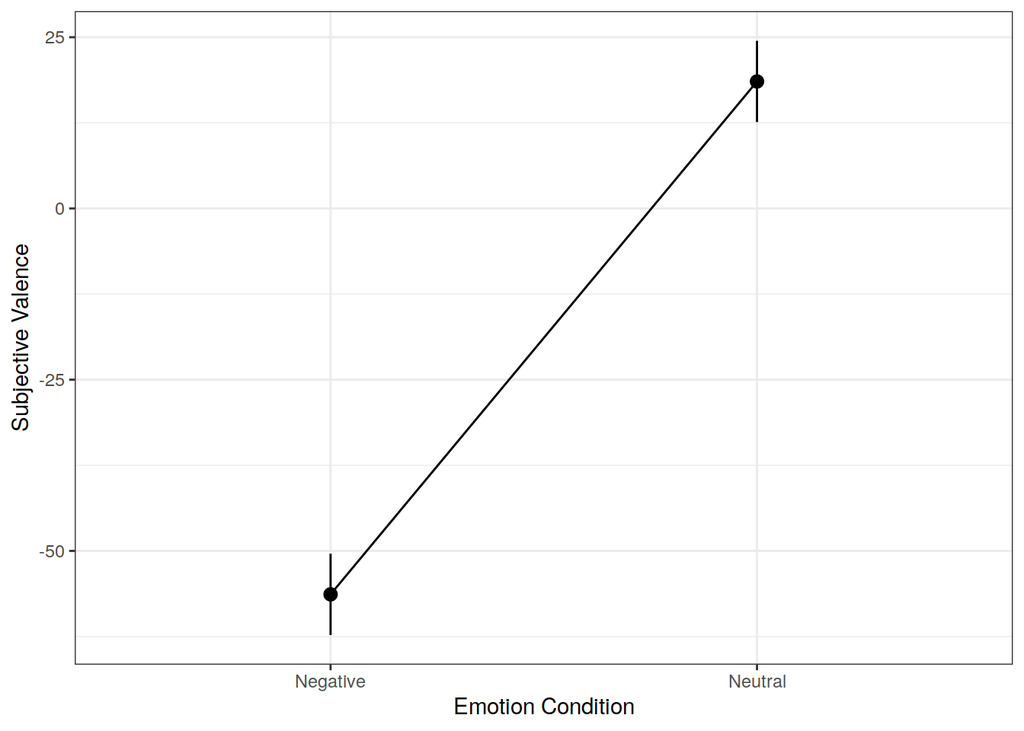

```r
library(ggplot2)

ggplot(means, aes(x=Emotion_Condition, y=Mean, group=1)) +
  geom_line() +
  geom_pointrange(aes(ymin=CI_lower, ymax=CI_higher)) +
  ylab("Subjective Valence") +
  xlab("Emotion Condition") +
  theme_bw()
```